# Linear Regression: Predicting House Prices in Mexico

## 1. Introduction and Context

In this analysis, we explore data from the Mexico real estate market to determine if property area (in square meters) can predict housing prices (in USD). The dataset contains information about various properties across different states in Mexico, including both houses and apartments.

```r
# Load the data
df <- read.csv("mexico-real-estate-clean.csv")

# Basic summary of the data
pander(summary(df[, c("area_m2", "price_usd")]))
```

| area_m2 | price_usd |
| --- | --- |
| Min. : 60.0 | Min. : 33158 |
| 1st Qu.:101.8 | 1st Qu.: 65790 |
| Median :156.0 | Median : 99262 |
| Mean :170.3 | Mean :115332 |
| 3rd Qu.:220.0 | 3rd Qu.:150847 |
| Max. :385.0 | Max. :326734 |

```r
# Count of property types
pander(table(df$property_type))
```

| apartment | house |
| --- | --- |
| 407 | 1329 |

The dataset includes 1736 properties with information about their type, location (state), area in square meters, and price in USD. The properties range from 60 to 385 square meters, with prices ranging from $33,157.89 to $326,733.7.

## 2. Linear Regression Hypotheses

For our linear regression analysis, we establish the following hypotheses:

- **Null Hypothesis (H₀)**: There is no linear relationship between property area and price (slope = 0).
- **Alternative Hypothesis (Hₐ)**: There is a significant linear relationship between property area and price (slope ≠ 0).
- **Level of Significance**: 0.05

## 3. Correlation and Scatterplot

First, let's examine the correlation between property area and price:

```r
# Calculate correlation
cor_val <- cor(df$area_m2, df$price_usd)
cat("Correlation between area_m2 and price_usd:", round(cor_val, 4))
```

```
## Correlation between area_m2 and price_usd: 0.5855
```

Now, let's visualize this relationship with a scatterplot:

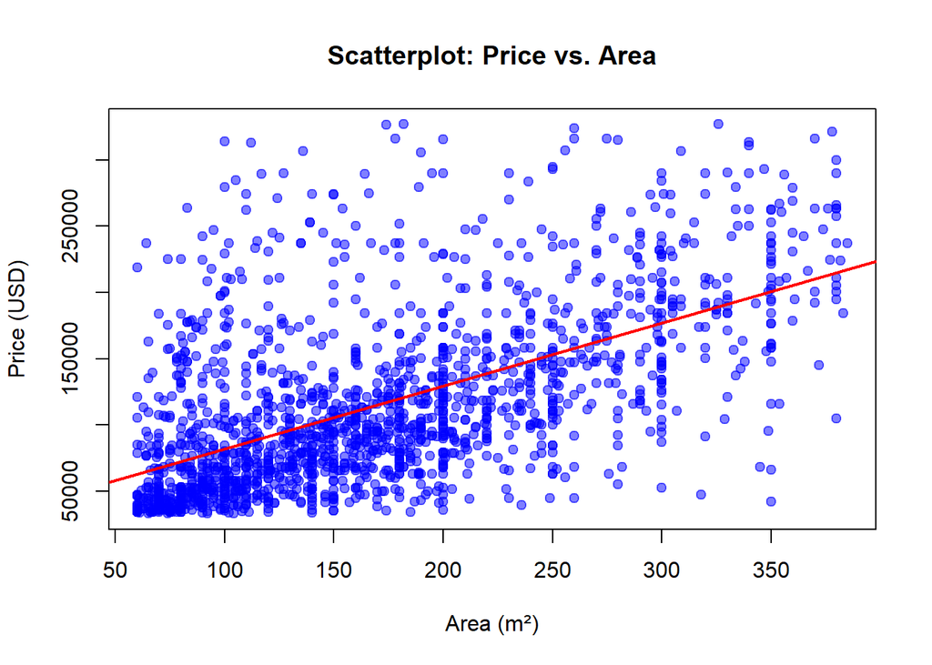

```r
# Create scatterplot with regression line
plot(df$area_m2, df$price_usd,
     main = "Scatterplot: Price vs. Area",
     xlab = "Area (m²)",
     ylab = "Price (USD)",
     pch = 19,
     col = adjustcolor("blue", alpha.f = 0.5))
abline(lm(price_usd ~ area_m2, data = df), col = "red", lwd = 2)
```

The scatterplot shows a positive relationship between property area and price, with a correlation coefficient of 0.5855. This indicates a moderate positive correlation between these variables.

## 4. Linear Regression Model

Now, let's fit a linear regression model to quantify this relationship:

```r
# Fit linear regression model
model <- lm(price_usd ~ area_m2, data = df)
pander(summary(model))
```

|  | Estimate | Std. Error | t value | Pr(>\|t\|) |
| --- | --- | --- | --- | --- |
| **(Intercept)** | 34403 | 2977 | 11.56 | 8.163e-30 |
| **area_m2** | 475.3 | 15.8 | 30.08 | 2.754e-160 |

Fitting linear model: price_usd ~ area_m2

| Observations | Residual Std. Error | $R^2$ | Adjusted $R^2$ |
| --- | --- | --- | --- |
| 1736 | 53054 | 0.3428 | 0.3425 |

## 5. Interpretation and Prediction

### Making a Prediction:

Let's predict the price for a property with 200 square meters:

```r
# Predict price for a 200 m² property
new_data <- data.frame(area_m2 = 200)
predicted_price <- predict(model, newdata = new_data)
cat("Predicted price for a 200 m² property: $", format(round(predicted_price, 2), big.mark=","))
```

```
## Predicted price for a 200 m² property: $ 129,467.3
```

## 6. Checking Model Requirements

To ensure the validity of our linear regression model, we need to check several assumptions:

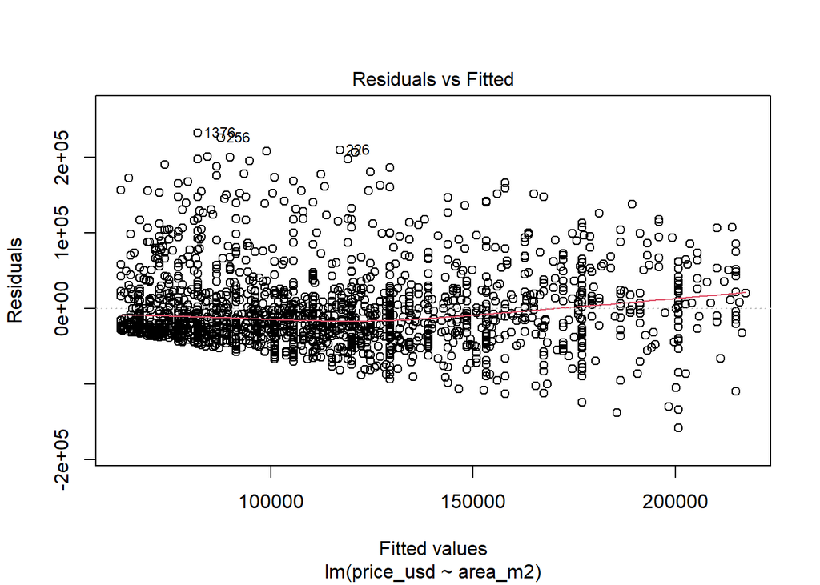

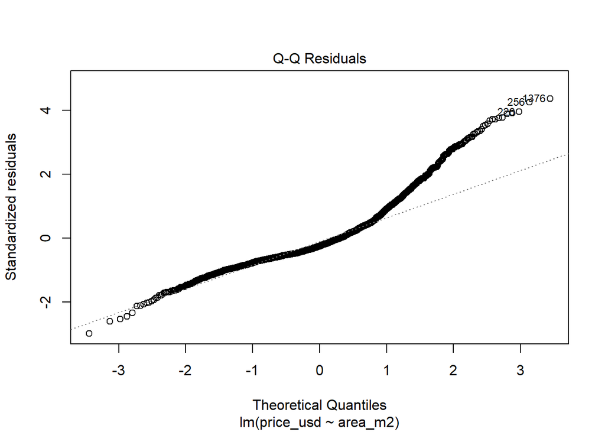

```r
# Diagnostic plots
par(mfrow=c(1,1))
plot(model, which=1:2)
```

## 7. Conclusions and Future Studies

Based on our analysis:

- There is a statistically significant relationship between property area and price (p-value < 2e-16).
- The model suggests that each additional square meter adds approximately $475.32 to the property price.
- The R-squared value of 0.3428 indicates that our model explains about 34.28% of the variability in housing prices.

### Limitations and Future Studies:

While our model provides valuable insights, it has limitations:

1. The relatively low R-squared value suggests that other factors beyond property area influence housing prices.
2. Future studies could incorporate additional predictors such as:
   - Property type (house vs. apartment)
   - Location (state, city, neighborhood)
   - Number of bedrooms and bathrooms
   - Property age and condition
   - Proximity to amenities
3. More complex models (multiple regression, non-linear models) might better capture the relationship between property characteristics and prices.

This analysis provides a foundation for understanding the Mexican real estate market, but further research with more comprehensive data would yield more robust insights for potential buyers, sellers, and investors.